# Risk Factor Analysis

## Outcome Variable

**Outcome Variable:** y_rate_haz

## Predictor Variables

**Intervention Variable:** hhwealth_quart

**Adjustment Set:**

unadjusted

## Stratifying Variables

The analysis was stratified on these variable(s):

- agecat
- studyid
- country

## Data Summary

| agecat | studyid | country | hhwealth_quart | n_cell | n |
| --- | --- | --- | --- | --- | --- |
| 0-3 months | COHORTS | GUATEMALA | Wealth Q4 | 248 | 709 |
| 0-3 months | COHORTS | GUATEMALA | Wealth Q1 | 138 | 709 |
| 0-3 months | COHORTS | GUATEMALA | Wealth Q2 | 140 | 709 |
| 0-3 months | COHORTS | GUATEMALA | Wealth Q3 | 183 | 709 |
| 3-6 months | COHORTS | GUATEMALA | Wealth Q4 | 284 | 780 |
| 3-6 months | COHORTS | GUATEMALA | Wealth Q1 | 146 | 780 |
| 3-6 months | COHORTS | GUATEMALA | Wealth Q2 | 156 | 780 |
| 3-6 months | COHORTS | GUATEMALA | Wealth Q3 | 194 | 780 |
| 6-9 months | COHORTS | GUATEMALA | Wealth Q4 | 298 | 799 |
| 6-9 months | COHORTS | GUATEMALA | Wealth Q1 | 156 | 799 |
| 6-9 months | COHORTS | GUATEMALA | Wealth Q2 | 166 | 799 |
| 6-9 months | COHORTS | GUATEMALA | Wealth Q3 | 179 | 799 |
| 9-12 months | COHORTS | GUATEMALA | Wealth Q4 | 335 | 898 |
| 9-12 months | COHORTS | GUATEMALA | Wealth Q1 | 179 | 898 |
| 9-12 months | COHORTS | GUATEMALA | Wealth Q2 | 184 | 898 |
| 9-12 months | COHORTS | GUATEMALA | Wealth Q3 | 200 | 898 |
| 12-15 months | COHORTS | GUATEMALA | Wealth Q4 | 329 | 855 |
| 12-15 months | COHORTS | GUATEMALA | Wealth Q1 | 161 | 855 |
| 12-15 months | COHORTS | GUATEMALA | Wealth Q2 | 184 | 855 |
| 12-15 months | COHORTS | GUATEMALA | Wealth Q3 | 181 | 855 |
| 15-18 months | COHORTS | GUATEMALA | Wealth Q4 | 291 | 772 |
| 15-18 months | COHORTS | GUATEMALA | Wealth Q1 | 146 | 772 |
| 15-18 months | COHORTS | GUATEMALA | Wealth Q2 | 169 | 772 |
| 15-18 months | COHORTS | GUATEMALA | Wealth Q3 | 166 | 772 |
| 18-21 months | COHORTS | GUATEMALA | Wealth Q4 | 281 | 765 |
| 18-21 months | COHORTS | GUATEMALA | Wealth Q1 | 149 | 765 |
| 18-21 months | COHORTS | GUATEMALA | Wealth Q2 | 162 | 765 |
| 18-21 months | COHORTS | GUATEMALA | Wealth Q3 | 173 | 765 |
| 21-24 months | COHORTS | GUATEMALA | Wealth Q4 | 312 | 843 |
| 21-24 months | COHORTS | GUATEMALA | Wealth Q1 | 166 | 843 |
| 21-24 months | COHORTS | GUATEMALA | Wealth Q2 | 177 | 843 |
| 21-24 months | COHORTS | GUATEMALA | Wealth Q3 | 188 | 843 |

The following strata were considered:

- agecat: 0-3 months, studyid: COHORTS, country: GUATEMALA
- agecat: 12-15 months, studyid: COHORTS, country: GUATEMALA
- agecat: 15-18 months, studyid: COHORTS, country: GUATEMALA
- agecat: 18-21 months, studyid: COHORTS, country: GUATEMALA
- agecat: 21-24 months, studyid: COHORTS, country: GUATEMALA
- agecat: 3-6 months, studyid: COHORTS, country: GUATEMALA
- agecat: 6-9 months, studyid: COHORTS, country: GUATEMALA
- agecat: 9-12 months, studyid: COHORTS, country: GUATEMALA

## Methods Detail

We’re interested in the causal parameters $E[Y_a]$ for all values of $a \in \mathcal{A}$. These parameters represent the mean outcome if, possibly contrary to fact, we intervened to set all units to have $A=a$. Under the randomization and positivity assumptions, these are identified by the statistical parameters $\psi_a=E_W[E_{Y|A,W}(Y|A=a,W)]$. In addition, we’re interested in the mean of $Y$, $E[Y]$ under no intervention (the observed mean). We will estimate these parameters by using SuperLearner to fit the relevant likelihood factors – $E_{Y|A,W}(Y|A=a,W)$ and $p(A=a|W)$, and then updating our likelihood fit using a joint TMLE.

For unadjusted analyses ($W=\{\}$), initial likelihoods were estimated using Lrnr_glm to estimate the simple $E(Y|A)$ and Lrnr_mean to estimate $p(A)$. For adjusted analyses, a small library containing Lrnr_glmnet, Lrnr_xgboost, and Lrnr_mean was used.

# Results Detail

## Results Plots

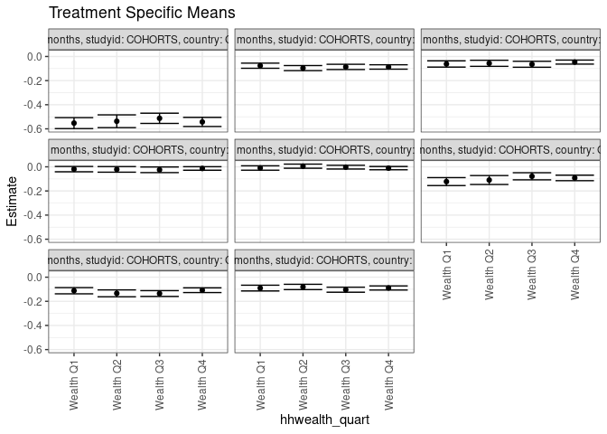

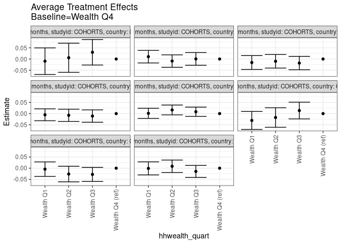

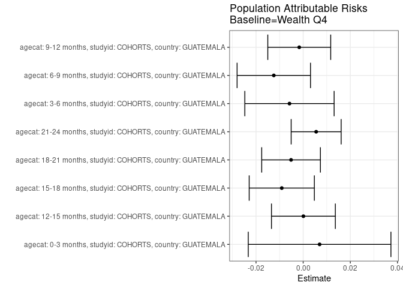

## Results Table

### Parameter: TSM

| agecat | studyid | country | intervention_level | baseline_level | estimate | ci_lower | ci_upper |
| --- | --- | --- | --- | --- | --- | --- | --- |
| 0-3 months | COHORTS | GUATEMALA | Wealth Q4 | NA | -0.5425329 | -0.5804544 | -0.5046114 |
| 0-3 months | COHORTS | GUATEMALA | Wealth Q1 | NA | -0.5523050 | -0.5977802 | -0.5068298 |
| 0-3 months | COHORTS | GUATEMALA | Wealth Q2 | NA | -0.5369194 | -0.5897643 | -0.4840745 |
| 0-3 months | COHORTS | GUATEMALA | Wealth Q3 | NA | -0.5124747 | -0.5547976 | -0.4701517 |
| 3-6 months | COHORTS | GUATEMALA | Wealth Q4 | NA | -0.0918641 | -0.1146787 | -0.0690495 |
| 3-6 months | COHORTS | GUATEMALA | Wealth Q1 | NA | -0.1223356 | -0.1553562 | -0.0893150 |
| 3-6 months | COHORTS | GUATEMALA | Wealth Q2 | NA | -0.1092965 | -0.1463958 | -0.0721971 |
| 3-6 months | COHORTS | GUATEMALA | Wealth Q3 | NA | -0.0782644 | -0.1077311 | -0.0487978 |
| 6-9 months | COHORTS | GUATEMALA | Wealth Q4 | NA | -0.1078384 | -0.1274965 | -0.0881803 |
| 6-9 months | COHORTS | GUATEMALA | Wealth Q1 | NA | -0.1121501 | -0.1378008 | -0.0864994 |
| 6-9 months | COHORTS | GUATEMALA | Wealth Q2 | NA | -0.1339194 | -0.1625223 | -0.1053164 |
| 6-9 months | COHORTS | GUATEMALA | Wealth Q3 | NA | -0.1355107 | -0.1596583 | -0.1113630 |
| 9-12 months | COHORTS | GUATEMALA | Wealth Q4 | NA | -0.0894155 | -0.1064012 | -0.0724297 |
| 9-12 months | COHORTS | GUATEMALA | Wealth Q1 | NA | -0.0903436 | -0.1140837 | -0.0666035 |
| 9-12 months | COHORTS | GUATEMALA | Wealth Q2 | NA | -0.0809450 | -0.1030649 | -0.0588250 |
| 9-12 months | COHORTS | GUATEMALA | Wealth Q3 | NA | -0.1038595 | -0.1246714 | -0.0830476 |
| 12-15 months | COHORTS | GUATEMALA | Wealth Q4 | NA | -0.0869217 | -0.1051310 | -0.0687124 |
| 12-15 months | COHORTS | GUATEMALA | Wealth Q1 | NA | -0.0764303 | -0.0977700 | -0.0550906 |
| 12-15 months | COHORTS | GUATEMALA | Wealth Q2 | NA | -0.0961029 | -0.1171224 | -0.0750834 |
| 12-15 months | COHORTS | GUATEMALA | Wealth Q3 | NA | -0.0864620 | -0.1082378 | -0.0646861 |
| 15-18 months | COHORTS | GUATEMALA | Wealth Q4 | NA | -0.0464809 | -0.0631457 | -0.0298161 |
| 15-18 months | COHORTS | GUATEMALA | Wealth Q1 | NA | -0.0620481 | -0.0880408 | -0.0360554 |
| 15-18 months | COHORTS | GUATEMALA | Wealth Q2 | NA | -0.0566539 | -0.0818822 | -0.0314257 |
| 15-18 months | COHORTS | GUATEMALA | Wealth Q3 | NA | -0.0646365 | -0.0893903 | -0.0398827 |
| 18-21 months | COHORTS | GUATEMALA | Wealth Q4 | NA | -0.0135570 | -0.0280543 | 0.0009403 |
| 18-21 months | COHORTS | GUATEMALA | Wealth Q1 | NA | -0.0189229 | -0.0410681 | 0.0032222 |
| 18-21 months | COHORTS | GUATEMALA | Wealth Q2 | NA | -0.0211847 | -0.0443686 | 0.0019992 |
| 18-21 months | COHORTS | GUATEMALA | Wealth Q3 | NA | -0.0245223 | -0.0479665 | -0.0010781 |
| 21-24 months | COHORTS | GUATEMALA | Wealth Q4 | NA | -0.0108303 | -0.0245295 | 0.0028688 |
| 21-24 months | COHORTS | GUATEMALA | Wealth Q1 | NA | -0.0096401 | -0.0277582 | 0.0084781 |
| 21-24 months | COHORTS | GUATEMALA | Wealth Q2 | NA | 0.0054773 | -0.0116802 | 0.0226348 |
| 21-24 months | COHORTS | GUATEMALA | Wealth Q3 | NA | -0.0025343 | -0.0181124 | 0.0130438 |

### Parameter: E(Y)

| agecat | studyid | country | intervention_level | baseline_level | estimate | ci_lower | ci_upper |
| --- | --- | --- | --- | --- | --- | --- | --- |
| 0-3 months | COHORTS | GUATEMALA | NA | NA | -0.5355682 | -0.5575602 | -0.5135762 |
| 3-6 months | COHORTS | GUATEMALA | NA | NA | -0.0976717 | -0.1124091 | -0.0829344 |
| 6-9 months | COHORTS | GUATEMALA | NA | NA | -0.1202982 | -0.1323063 | -0.1082902 |
| 9-12 months | COHORTS | GUATEMALA | NA | NA | -0.0910818 | -0.1013201 | -0.0808435 |
| 12-15 months | COHORTS | GUATEMALA | NA | NA | -0.0868247 | -0.0971751 | -0.0764742 |
| 15-18 months | COHORTS | GUATEMALA | NA | NA | -0.0555559 | -0.0666347 | -0.0444771 |
| 18-21 months | COHORTS | GUATEMALA | NA | NA | -0.0186971 | -0.0286605 | -0.0087338 |
| 21-24 months | COHORTS | GUATEMALA | NA | NA | -0.0053218 | -0.0133012 | 0.0026576 |

### Parameter: ATE

| agecat | studyid | country | intervention_level | baseline_level | estimate | ci_lower | ci_upper |
| --- | --- | --- | --- | --- | --- | --- | --- |
| 0-3 months | COHORTS | GUATEMALA | Wealth Q4 | Wealth Q4 | 0.0000000 | 0.0000000 | 0.0000000 |
| 0-3 months | COHORTS | GUATEMALA | Wealth Q1 | Wealth Q4 | -0.0097721 | -0.0689838 | 0.0494397 |
| 0-3 months | COHORTS | GUATEMALA | Wealth Q2 | Wealth Q4 | 0.0056135 | -0.0594297 | 0.0706567 |
| 0-3 months | COHORTS | GUATEMALA | Wealth Q3 | Wealth Q4 | 0.0300583 | -0.0267684 | 0.0868849 |
| 3-6 months | COHORTS | GUATEMALA | Wealth Q4 | Wealth Q4 | 0.0000000 | 0.0000000 | 0.0000000 |
| 3-6 months | COHORTS | GUATEMALA | Wealth Q1 | Wealth Q4 | -0.0304715 | -0.0706071 | 0.0096641 |
| 3-6 months | COHORTS | GUATEMALA | Wealth Q2 | Wealth Q4 | -0.0174323 | -0.0609854 | 0.0261207 |
| 3-6 months | COHORTS | GUATEMALA | Wealth Q3 | Wealth Q4 | 0.0135997 | -0.0236668 | 0.0508662 |
| 6-9 months | COHORTS | GUATEMALA | Wealth Q4 | Wealth Q4 | 0.0000000 | 0.0000000 | 0.0000000 |
| 6-9 months | COHORTS | GUATEMALA | Wealth Q1 | Wealth Q4 | -0.0043117 | -0.0366289 | 0.0280055 |
| 6-9 months | COHORTS | GUATEMALA | Wealth Q2 | Wealth Q4 | -0.0260810 | -0.0607879 | 0.0086260 |
| 6-9 months | COHORTS | GUATEMALA | Wealth Q3 | Wealth Q4 | -0.0276723 | -0.0588099 | 0.0034654 |
| 9-12 months | COHORTS | GUATEMALA | Wealth Q4 | Wealth Q4 | 0.0000000 | 0.0000000 | 0.0000000 |
| 9-12 months | COHORTS | GUATEMALA | Wealth Q1 | Wealth Q4 | -0.0009282 | -0.0301191 | 0.0282627 |
| 9-12 months | COHORTS | GUATEMALA | Wealth Q2 | Wealth Q4 | 0.0084705 | -0.0194187 | 0.0363597 |
| 9-12 months | COHORTS | GUATEMALA | Wealth Q3 | Wealth Q4 | -0.0144440 | -0.0413076 | 0.0124195 |
| 12-15 months | COHORTS | GUATEMALA | Wealth Q4 | Wealth Q4 | 0.0000000 | 0.0000000 | 0.0000000 |
| 12-15 months | COHORTS | GUATEMALA | Wealth Q1 | Wealth Q4 | 0.0104914 | -0.0175614 | 0.0385442 |
| 12-15 months | COHORTS | GUATEMALA | Wealth Q2 | Wealth Q4 | -0.0091811 | -0.0369912 | 0.0186289 |
| 12-15 months | COHORTS | GUATEMALA | Wealth Q3 | Wealth Q4 | 0.0004598 | -0.0279263 | 0.0288458 |
| 15-18 months | COHORTS | GUATEMALA | Wealth Q4 | Wealth Q4 | 0.0000000 | 0.0000000 | 0.0000000 |
| 15-18 months | COHORTS | GUATEMALA | Wealth Q1 | Wealth Q4 | -0.0155672 | -0.0464434 | 0.0153089 |
| 15-18 months | COHORTS | GUATEMALA | Wealth Q2 | Wealth Q4 | -0.0101730 | -0.0404084 | 0.0200623 |
| 15-18 months | COHORTS | GUATEMALA | Wealth Q3 | Wealth Q4 | -0.0181556 | -0.0479963 | 0.0116851 |
| 18-21 months | COHORTS | GUATEMALA | Wealth Q4 | Wealth Q4 | 0.0000000 | 0.0000000 | 0.0000000 |
| 18-21 months | COHORTS | GUATEMALA | Wealth Q1 | Wealth Q4 | -0.0053659 | -0.0318344 | 0.0211025 |
| 18-21 months | COHORTS | GUATEMALA | Wealth Q2 | Wealth Q4 | -0.0076277 | -0.0349712 | 0.0197157 |
| 18-21 months | COHORTS | GUATEMALA | Wealth Q3 | Wealth Q4 | -0.0109653 | -0.0385298 | 0.0165992 |
| 21-24 months | COHORTS | GUATEMALA | Wealth Q4 | Wealth Q4 | 0.0000000 | 0.0000000 | 0.0000000 |
| 21-24 months | COHORTS | GUATEMALA | Wealth Q1 | Wealth Q4 | 0.0011903 | -0.0215240 | 0.0239045 |
| 21-24 months | COHORTS | GUATEMALA | Wealth Q2 | Wealth Q4 | 0.0163077 | -0.0056479 | 0.0382632 |
| 21-24 months | COHORTS | GUATEMALA | Wealth Q3 | Wealth Q4 | 0.0082960 | -0.0124487 | 0.0290408 |

### Parameter: PAR

| agecat | studyid | country | intervention_level | baseline_level | estimate | ci_lower | ci_upper |
| --- | --- | --- | --- | --- | --- | --- | --- |
| 0-3 months | COHORTS | GUATEMALA | Wealth Q4 | NA | 0.0069647 | -0.0232953 | 0.0372248 |
| 3-6 months | COHORTS | GUATEMALA | Wealth Q4 | NA | -0.0058076 | -0.0247460 | 0.0131307 |
| 6-9 months | COHORTS | GUATEMALA | Wealth Q4 | NA | -0.0124598 | -0.0280283 | 0.0031086 |
| 9-12 months | COHORTS | GUATEMALA | Wealth Q4 | NA | -0.0016663 | -0.0150109 | 0.0116782 |
| 12-15 months | COHORTS | GUATEMALA | Wealth Q4 | NA | 0.0000971 | -0.0134502 | 0.0136444 |
| 15-18 months | COHORTS | GUATEMALA | Wealth Q4 | NA | -0.0090750 | -0.0228985 | 0.0047485 |
| 18-21 months | COHORTS | GUATEMALA | Wealth Q4 | NA | -0.0051401 | -0.0175916 | 0.0073113 |
| 21-24 months | COHORTS | GUATEMALA | Wealth Q4 | NA | 0.0055085 | -0.0050945 | 0.0161115 |